# AB testing data

Kevin Wang

Initiated on 2018 Apr 02, compiled on 2020 Apr 10

# 1 Loading packages

```r
library(tidyverse)
library(readxl)
library(skimr)
library(janitor)
```

# 2 Loading functions

```r
theme_set(theme_classic(18) +
            theme(legend.position = "bottom"))
```

# 3 Loading data

```r
raw_data = read_csv("ab_data.csv") %>%
  dplyr::mutate(user_id = user_id %>% as.character,
                converted = converted %>% as.character) %>%
  dplyr::arrange(timestamp) %>%
  group_by(user_id) %>%
  add_count(name = "user_count") %>%
  ungroup()
```

# 4 Basic reporting of characteristics

```r
raw_data$user_count %>% table
```

```
## .
##      1      2
## 286690   7788
```

Note that there are multiple sessions for a single given user.

The landing page and the group seem to be duplicated information. Let’s check.

```r
raw_data %>%
  tabyl(group, landing_page) %>%
  janitor::adorn_totals()
```

```
##      group new_page old_page
##    control     1928   145274
##  treatment   145311     1965
##      Total   147239   147239
```

```r
raw_data %>%
  tabyl(group, landing_page) %>%
  janitor::adorn_totals(where = "col")
```

```
##      group new_page old_page  Total
##    control     1928   145274 147202
##  treatment   145311     1965 147276
```

```r
raw_data %>%
  tabyl(group, landing_page) %>%
  janitor::adorn_percentages(denominator = "all")
```

```
##      group    new_page    old_page
##    control 0.006547178 0.493327176
##  treatment 0.493452822 0.006672824
```

No, it is not, but the original data descriptions did not say what are the differences between the two in the original design of the experiment.

Note that the totals for the samples are too perfect. So I wouldn’t be surprised if the data has ben manually cut into equal proportions.

## 4.1 Using only aligned data

```r
aligned_data = raw_data %>%
  dplyr::filter((landing_page == "new_page" & group == "treatment") |
                  (landing_page == "old_page" & group == "control"))

dim(aligned_data)
```

```
## [1] 290585      6
```

```r
aligned_data %>%
  tabyl(group, landing_page) %>%
  janitor::adorn_percentages(denominator = "all")
```

```
##      group  new_page  old_page
##    control 0.0000000 0.4999363
##  treatment 0.5000637 0.0000000
```

## 4.2 Getting duplicated users from

```r
aligned_data %>%
  janitor::get_dupes(user_id)
```

```
## # A tibble: 2 x 7
##   user_id dupe_count timestamp           group landing_page converted user_count
##   <chr>        <int> <dttm>              <chr> <chr>        <chr>          <int>
## 1 773192           2 2017-01-09 05:37:58 trea… new_page     0                  2
## 2 773192           2 2017-01-14 02:55:59 trea… new_page     0                  2
```

So, based on this output, I would guess all the mis-aligned entries are those users who visited the site more than once and landed on both sides of control and treatment. Let’s check

```r
raw_data %>%
  tabyl(group, landing_page, user_count) %>%
  janitor::adorn_totals()
```

```
## $`1`
##      group new_page old_page
##    control        0   143293
##  treatment   143397        0
##      Total   143397   143293
##
## $`2`
##      group new_page old_page
##    control     1928     1981
##  treatment     1914     1965
##      Total     3842     3946
```

Yes, we see that if the user only visited once, then these entries are always aligned. But if users visited the site more than once, then that is a bit different.

It will be interesting to know how differently the returning users behave compare to the unique visited users. So this is our hypothesis based on the IDE: **returning users will have a higher conversion rate than the unique visited users**. Let’s try some visualisations first.

# 5 Visualisations

```r
summ_data = raw_data %>%
  group_by(group, landing_page, user_count, converted) %>%
  tally() %>%
  dplyr::mutate(perc_converted = n/sum(n))

summ_data
```

```
## # A tibble: 12 x 6
## # Groups:   group, landing_page, user_count [6]
##    group     landing_page user_count converted      n perc_converted
##    <chr>     <chr>             <int> <chr>      <int>          <dbl>
##  1 control   new_page              2 0           1694          0.879
##  2 control   new_page              2 1            234          0.121
##  3 control   old_page              1 0         126073          0.880
##  4 control   old_page              1 1          17220          0.120
##  5 control   old_page              2 0           1712          0.864
##  6 control   old_page              2 1            269          0.136
##  7 treatment new_page              1 0         126372          0.881
##  8 treatment new_page              1 1          17025          0.119
##  9 treatment new_page              2 0           1675          0.875
## 10 treatment new_page              2 1            239          0.125
## 11 treatment old_page              2 0           1715          0.873
## 12 treatment old_page              2 1            250          0.127
```

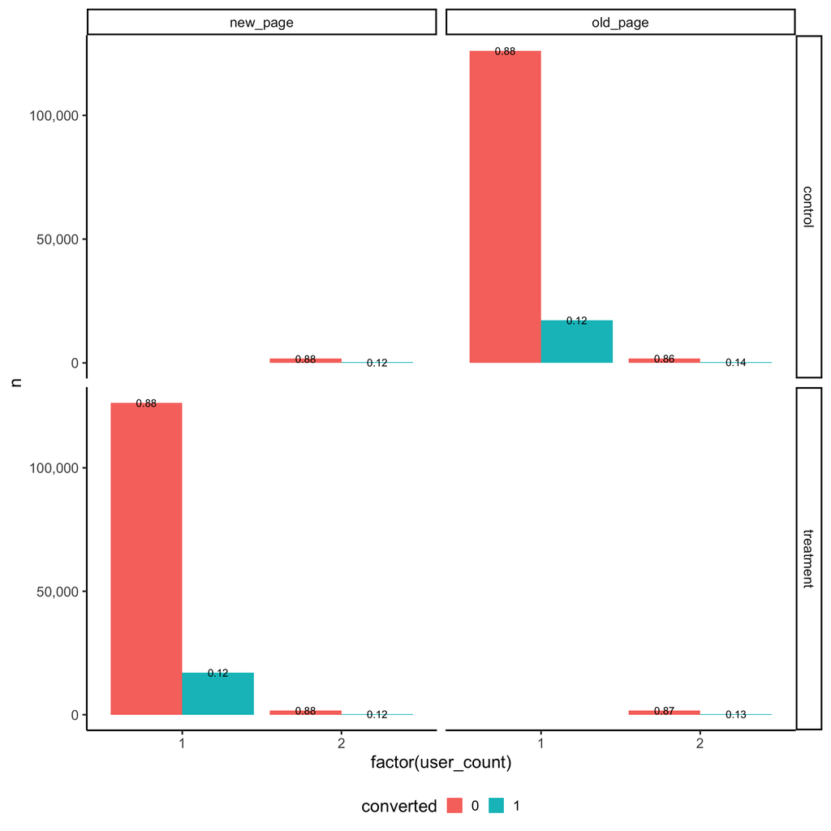

```r
summ_data %>%
  ggplot(aes(x = factor(user_count), y = n,
             fill = converted)) +
  geom_col(position = "dodge") +
  geom_text(aes(label = signif(perc_converted, 2)),
            position = position_dodge(width = 0.9)) +
  facet_grid(group ~ landing_page, scales = "free") +
  scale_y_continuous(labels = scales::comma)
```

Based on this plot, I am pretty confident in saying that there won’t be a significant difference between the two versions, even tyring to resolve the data at the level of multiple users. So let’s proceed to performing the proportion test, for multiple users and for single users.

# 6 Single users

```r
single_data = raw_data %>%
  dplyr::filter(user_count == 1)

single_table = single_data %>%
  tabyl(landing_page, converted) %>%
  janitor::adorn_totals(where = "col")

single_table
```

```
##  landing_page      0     1  Total
##      new_page 126372 17025 143397
##      old_page 126073 17220 143293
```

```r
prop.test(x = single_table[,"1"],
          n = single_table[,"Total"])
```

```
##
##  2-sample test for equality of proportions with continuity correction
##
## data:  single_table[, "1"] out of single_table[, "Total"]
## X-squared = 1.4131, df = 1, p-value = 0.2345
## alternative hypothesis: two.sided
## 95 percent confidence interval:
##  -0.0038283237  0.0009342879
## sample estimates:
##    prop 1    prop 2
## 0.1187263 0.1201734
```

# 7 Multiple users

```r
multiple_data = raw_data %>%
  dplyr::filter(user_count == 2)

multiple_table = multiple_data %>%
  tabyl(landing_page, converted) %>%
  janitor::adorn_totals(where = "col")

multiple_table
```

```
##  landing_page    0   1 Total
##      new_page 3369 473  3842
##      old_page 3427 519  3946
```

```r
prop.test(x = single_table[,"1"],
          n = single_table[,"Total"])
```

```
##
##  2-sample test for equality of proportions with continuity correction
##
## data:  single_table[, "1"] out of single_table[, "Total"]
## X-squared = 1.4131, df = 1, p-value = 0.2345
## alternative hypothesis: two.sided
## 95 percent confidence interval:
##  -0.0038283237  0.0009342879
## sample estimates:
##    prop 1    prop 2
## 0.1187263 0.1201734
```

## 7.1 Logistic regression

It is still unclear to me why would you be placed in a control group and end up with the new_page, or in the treatment group and end up with the old_page. But if these two variables are genuinely different, then we should do some investigations using logistic regression to check up on the proportions.

```r
glm(as.integer(converted) ~ group * landing_page,
    family = "binomial", data = multiple_data) %>%
  broom::tidy()
```

```
## # A tibble: 4 x 5
##   term                                estimate std.error statistic   p.value
##   <chr>                                  <dbl>     <dbl>     <dbl>     <dbl>
## 1 (Intercept)                          -1.98      0.0697   -28.4   3.18e-177
## 2 grouptreatment                        0.0324    0.0982     0.330 7.41e-  1
## 3 landing_pageold_page                  0.129     0.0957     1.35  1.78e-  1
## 4 grouptreatment:landing_pageold_page  -0.107     0.136     -0.789 4.30e-  1
```

# 8 Are latter visits by the users more successful?

If a user visited the site multiple times, can we check if the latter visit is more successful at conversion?

```r
multiple_data = multiple_data %>%
  group_by(user_id) %>%
  dplyr::mutate(index_visit = seq_len(n())) %>%
  ungroup()

multiple_data %>%
  tabyl(index_visit, converted, landing_page) %>%
  # janitor::adorn_totals(where = "col") %>%
  janitor::adorn_percentages(denominator = "row")
```

```
## $new_page
##  index_visit         0         1
##            1 0.8806758 0.1193242
##            2 0.8732033 0.1267967
##
## $old_page
##  index_visit         0         1
##            1 0.8550000 0.1450000
##            2 0.8823227 0.1176773
```

# 9 Seasonality

```r
library(lubridate)
```

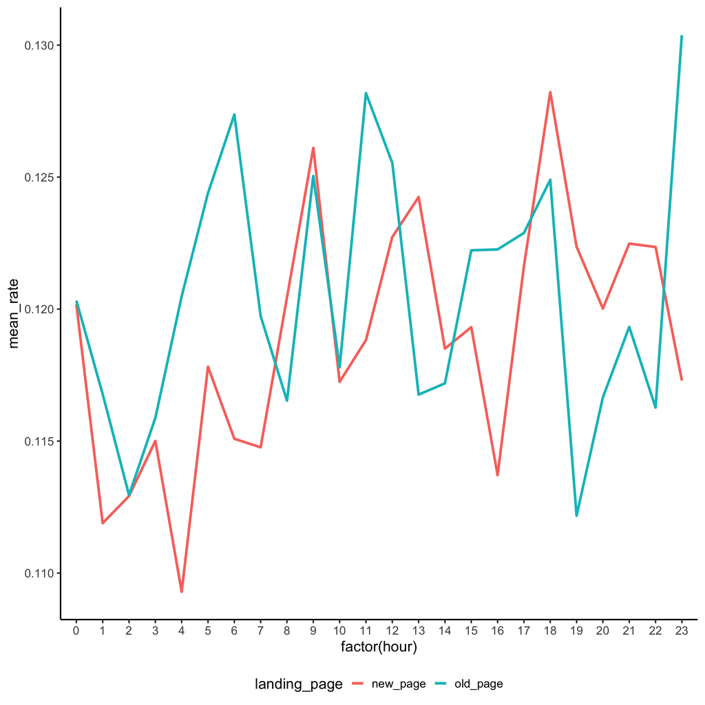

```r
raw_data_summ = raw_data %>%
  group_by(landing_page, hour = hour(timestamp)) %>%
  summarise(mean_rate = mean(as.integer(converted)),
            n = n()) %>%
  ungroup()

raw_data_summ %>%
  ggplot(aes(x = factor(hour), y = mean_rate,
             colour = landing_page, group = landing_page)) +
  geom_path(size = 1.5)
```

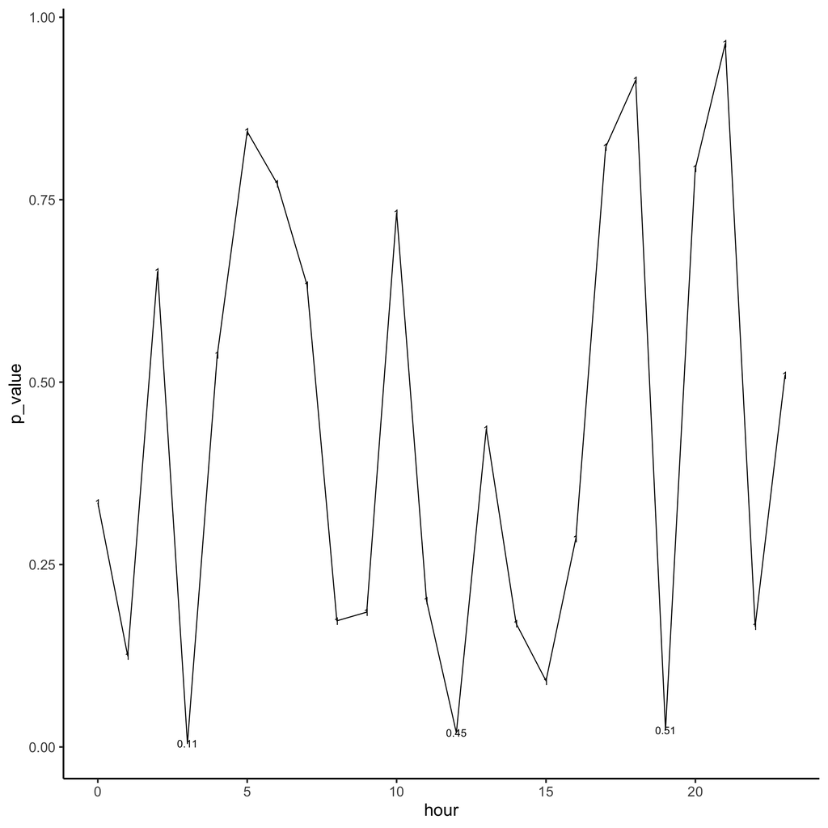

```r
raw_data_summ %>%
  dplyr::select(-mean_rate) %>%
  pivot_wider(names_from = landing_page,
              values_from = n) %>%
  group_by(hour) %>%
  dplyr::mutate(prop_test = purrr::map2(
    .x = old_page,
    .y = new_page,
    .f = ~ prop.test(x = .y, n = .x + .y)),
    p_value = purrr::map_dbl(prop_test, "p.value")) %>%
  ungroup() %>%
  dplyr::mutate(p_adj = p.adjust(p_value)) %>%
  ggplot(aes(x = hour, y = p_value)) +
  geom_path() +
  geom_text(aes(label = signif(p_adj, 2)))
```

# 10 Sample size calculations

If the original experiment is aimed at testing for only 1-2% effects, then it will be interesting to know if the number of samples we obtained are sufficient. We will operate on the single users only.

```r
single_data %>% dim
```

```
## [1] 286690      6
```

```r
library(pwr)

pwr::pwr.p.test(h = 0.01, n = NULL,
                sig.level = 0.05, power = 0.8,
                alternative = "two.sided")
```

```
##
##      proportion power calculation for binomial distribution (arcsine transformation)
##
##               h = 0.01
##               n = 78488.61
##       sig.level = 0.05
##           power = 0.8
##     alternative = two.sided
```

```r
pwr::pwr.p.test(h = 0.02, n = NULL,
                sig.level = 0.05, power = 0.8,
                alternative = "two.sided")
```

```
##
##      proportion power calculation for binomial distribution (arcsine transformation)
##
##               h = 0.02
##               n = 19622.15
##       sig.level = 0.05
##           power = 0.8
##     alternative = two.sided
```

```r
pwr.p.test(h = ES.h(p1 = 0.13, p2 = 0.12),
           sig.level = 0.05,
           power = 0.80,
           alternative = "two.sided")
```

```
##
##      proportion power calculation for binomial distribution (arcsine transformation)
##
##               h = 0.03024276
##               n = 8581.513
##       sig.level = 0.05
##           power = 0.8
##     alternative = two.sided
```

```r
pwr.2p.test(h = ES.h(p1 = 0.13, p2 = 0.12),
            sig.level = 0.05,
            power = 0.80,
            alternative = "two.sided")
```

```
##
##      Difference of proportion power calculation for binomial distribution (arcsine transformation)
##
##               h = 0.03024276
##               n = 17163.03
##       sig.level = 0.05
##           power = 0.8
##     alternative = two.sided
##
## NOTE: same sample sizes
```